# Crow Fault Bars

Justin Mann

2024-11-12

```r
library(tidyverse)
library(lme4)
library(nnet)
library(broom)
library(glmmTMB)
library(MCMCglmm)
library(DHARMa)
library(bbmle)
theme_set(theme_classic())
```

```r
fbs.df <- read.csv("FeatherMaster_1Nov24.csv", h=T)
fbs.df <- fbs.df[,1:15]
fbs.df$ID <- as.factor(fbs.df$ID)
n_occur <- data.frame(table(fbs.df$ID))
n_occur[n_occur$Freq > 1,]#no repeat IDs
```

```
## [1] Var1 Freq
## <0 rows> (or 0-length row.names)
```

```r
fbs.df$LightPlusMedium <- fbs.df$LightBars + fbs.df$MediumBars #a column combining light and medium bars
```

### Sums of light fault bars in urban and rural habitats

```r
sum(fbs.df$LightBars[fbs.df$Habitat=="urban"]) #200 urban light bars
```

```
## [1] 200
```

```r
sum(fbs.df$LightBars[fbs.df$Habitat=="rural"]) #300 rural light bars
```

```
## [1] 300
```

### Gausian linear model for light fault bars.

This model uses a Gaussian probability distribution which is not appropriate for count data.

```r
summary(lm(data = fbs.df, LightBars ~ Habitat))
```

```
##
## Call:
## lm(formula = LightBars ~ Habitat, data = fbs.df)
##
## Residuals:
##     Min      1Q  Median      3Q     Max
## -3.2967 -2.2727 -1.2967  0.7273 16.7273
##
## Coefficients:
##              Estimate Std. Error t value Pr(>|t|)
## (Intercept)    3.2967     0.3967   8.311 2.42e-14 ***
## Habitaturban  -1.0240     0.5657  -1.810    0.072 .
## ---
## Signif. codes:  0 '***' 0.001 '**' 0.01 '*' 0.05 '.' 0.1 ' ' 1
##
## Residual standard error: 3.784 on 177 degrees of freedom
## Multiple R-squared:  0.01817,    Adjusted R-squared:  0.01262
## F-statistic: 3.276 on 1 and 177 DF,  p-value: 0.072
```

### Poisson model for light fault bars.

```r
light.poisson.mdl <- (glm(data = fbs.df, LightBars ~ Habitat, family = "poisson"))
```

### DHARMa package zero inflation test

Significantly zero inflated

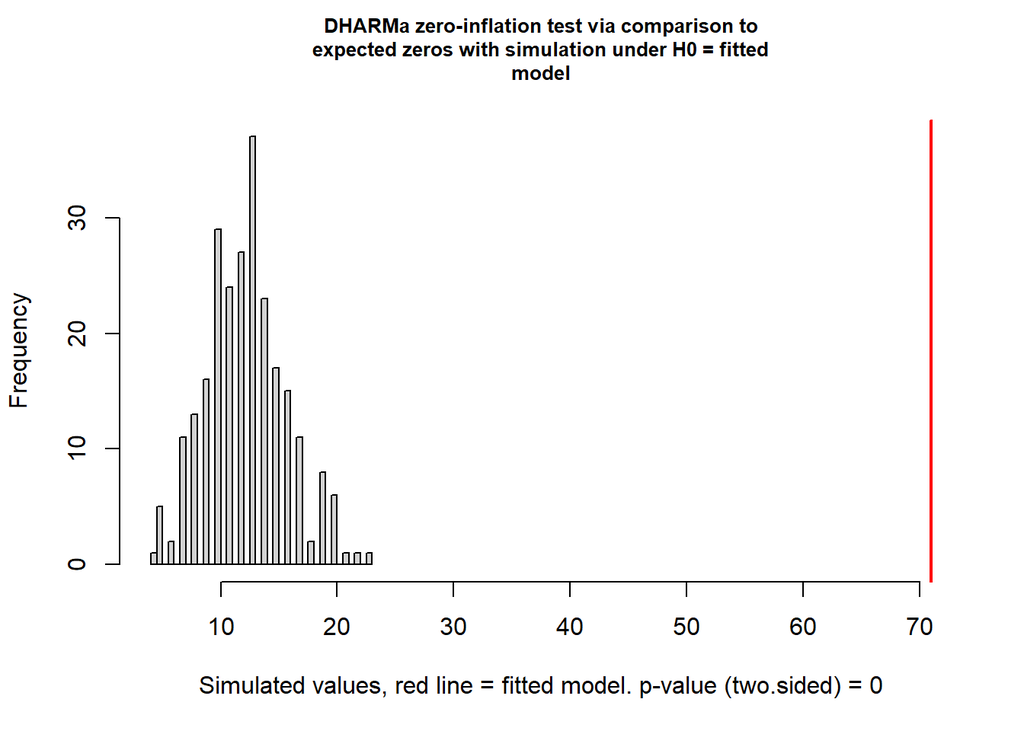

```
##
##  DHARMa zero-inflation test via comparison to expected zeros with
##  simulation under H0 = fitted model
##
## data:  simulationOutput
## ratioObsSim = 5.7203, p-value < 2.2e-16
## alternative hypothesis: two.sided
```

```r
light.res.sim <- simulateResiduals(light.poisson.mdl)
testZeroInflation(light.res.sim)
```

### DHARMa package overdispersion test

Significantly overdispersed. This means that we should be using a negative binomial distribution which has an overdispersion parameter.

```r
testOverdispersion(light.res.sim)
```

```
## testOverdispersion is deprecated, switch your code to using the testDispersion function
```

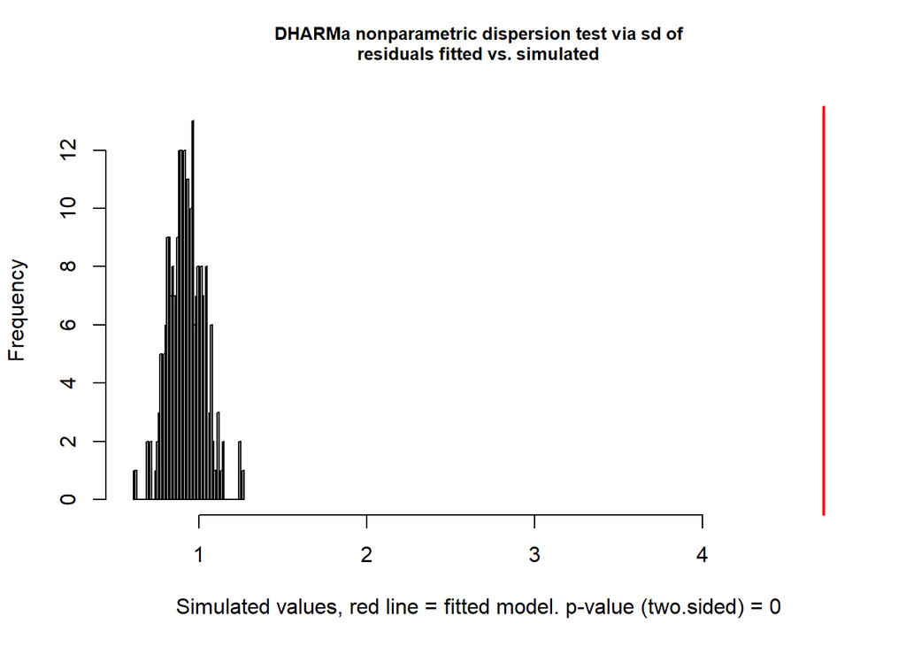

```
##
##  DHARMa nonparametric dispersion test via sd of residuals fitted vs.
##  simulated
##
## data:  simulationOutput
## dispersion = 5.1481, p-value < 2.2e-16
## alternative hypothesis: two.sided
```

### Zero-inflated poisson model

```r
light.ZIP.mdl <- glmmTMB(data = fbs.df, LightBars ~ Habitat, ziformula = ~1, family = "poisson")
```

### Light fault bar AIC model comparison

This output suggests that the negative binomial 2 distribution provides the best fit.

```r
light.ZINB1.mdl <- update(light.ZIP.mdl, family = nbinom1)
light.ZINB2.mdl <- update(light.ZIP.mdl, family = nbinom2)
AICtab(light.poisson.mdl, light.ZIP.mdl, light.ZINB1.mdl, light.ZINB2.mdl)
```

```
##                   dAIC  df
## light.ZINB2.mdl     0.0 4
## light.ZINB1.mdl     1.1 4
## light.ZIP.mdl     115.8 3
## light.poisson.mdl 372.6 2
```

### Best fit light fault bar model

```r
summary(light.ZINB2.mdl)
```

```
##  Family: nbinom2  ( log )
## Formula:          LightBars ~ Habitat
## Zero inflation:             ~1
## Data: fbs.df
##
##      AIC      BIC   logLik deviance df.resid
##    767.1    779.8   -379.5    759.1      175
##
##
## Dispersion parameter for nbinom2 family (): 1.12
##
## Conditional model:
##              Estimate Std. Error z value Pr(>|z|)
## (Intercept)    1.4644     0.1555   9.420   <2e-16 ***
## Habitaturban  -0.3523     0.1981  -1.779   0.0753 .
## ---
## Signif. codes:  0 '***' 0.001 '**' 0.01 '*' 0.05 '.' 0.1 ' ' 1
##
## Zero-inflation model:
##             Estimate Std. Error z value Pr(>|z|)
## (Intercept)   -1.125      0.414  -2.718  0.00657 **
## ---
## Signif. codes:  0 '***' 0.001 '**' 0.01 '*' 0.05 '.' 0.1 ' ' 1
```

### Light fault bar density plot

This plot shows the frequency of light fault bar numbers per feather in the urban and rural samples. The dotted lines are the habitat means.

```r
mean(fbs.df$LightBars[fbs.df$Habitat=="urban"])
```

```
## [1] 2.272727
```

```r
mean(fbs.df$LightBars[fbs.df$Habitat=="rural"])
```

```
## [1] 3.296703
```

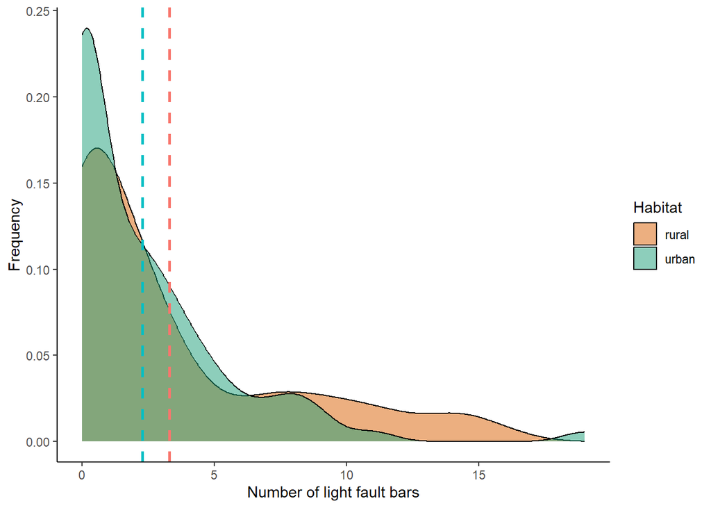

```r
Habitat <- c("Urban", "Rural")
Means <- c(2.27, 3.3)
HabitatMeans <- data.frame(Habitat,Means)

LightBarDensity.plot <- ggplot(fbs.df, aes(x=LightBars, fill = Habitat))+
  geom_density(alpha=0.5)+
  geom_vline(data = HabitatMeans, aes(xintercept = Means, color=Habitat),
             linetype="dashed",
             size = 1,
             show.legend = FALSE)+
  scale_fill_manual(values = c("#D95F02", "#1B9E77"))+
  ylab("Frequency")+
  xlab("Number of light fault bars")
LightBarDensity.plot
```

### Sum of medium fault bars in urban and rural habitats

```r
sum(fbs.df$MediumBars[fbs.df$Habitat=="urban"])
```

```
## [1] 114
```

```r
sum(fbs.df$MediumBars[fbs.df$Habitat=="rural"])
```

```
## [1] 181
```

### Poisson model for medium fault bars

```r
medium.poisson.mdl <- glmmTMB(data = fbs.df, MediumBars ~ Habitat, family = "poisson")
```

### Zero inflation test for medium fault bars

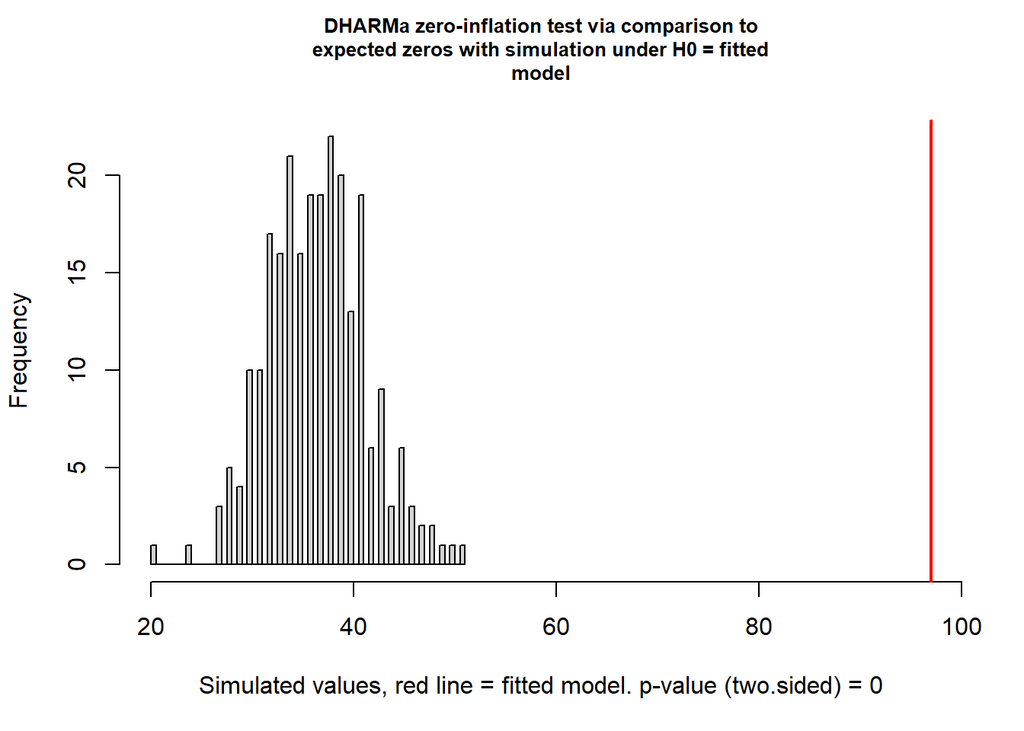

```
##
##  DHARMa zero-inflation test via comparison to expected zeros with
##  simulation under H0 = fitted model
##
## data:  simulationOutput
## ratioObsSim = 2.648, p-value < 2.2e-16
## alternative hypothesis: two.sided
```

```r
medium.res.sim <- simulateResiduals(medium.poisson.mdl)
testZeroInflation(medium.res.sim)
```

### Overdispersion test for medium fault bars

```r
testOverdispersion(medium.res.sim)
```

```
## testOverdispersion is deprecated, switch your code to using the testDispersion function
```

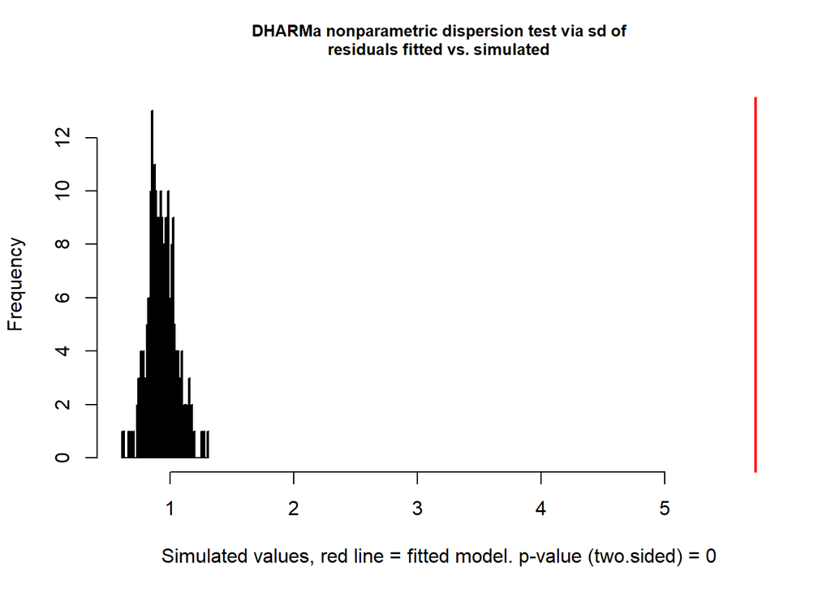

```
##
##  DHARMa nonparametric dispersion test via sd of residuals fitted vs.
##  simulated
##
## data:  simulationOutput
## dispersion = 6.1359, p-value < 2.2e-16
## alternative hypothesis: two.sided
```

### Medium fault bar ZIP model

```r
medium.ZIP.mdl <- glmmTMB(data = fbs.df, MediumBars ~ Habitat, ziformula = ~1, family = "poisson")
```

### Medium fault bar AIC model comparison

This output suggests that the negative binomial 1 distribution provides the best fit.

```r
medium.ZINB1.mdl <- update(medium.ZIP.mdl, family = nbinom1)
medium.ZINB2.mdl <- update(medium.ZIP.mdl, family = nbinom2)
AICtab(medium.poisson.mdl, medium.ZIP.mdl, medium.ZINB1.mdl, medium.ZINB2.mdl)
```

```
##                    dAIC  df
## medium.ZINB1.mdl     0.0 4
## medium.ZINB2.mdl     2.5 4
## medium.ZIP.mdl     134.0 3
## medium.poisson.mdl 337.5 2
```

### Best fit medium fault bar model

This model shows significantly fewer medium fault bars in the urban population

```r
summary(medium.ZINB1.mdl)
```

```
##  Family: nbinom1  ( log )
## Formula:          MediumBars ~ Habitat
## Zero inflation:              ~1
## Data: fbs.df
##
##      AIC      BIC   logLik deviance df.resid
##    591.4    604.2   -291.7    583.4      175
##
##
## Dispersion parameter for nbinom1 family (): 4.77
##
## Conditional model:
##              Estimate Std. Error z value Pr(>|z|)
## (Intercept)    0.7064     0.1625   4.348 1.37e-05 ***
## Habitaturban  -0.4781     0.2207  -2.166   0.0303 *
## ---
## Signif. codes:  0 '***' 0.001 '**' 0.01 '*' 0.05 '.' 0.1 ' ' 1
##
## Zero-inflation model:
##             Estimate Std. Error z value Pr(>|z|)
## (Intercept)   -18.56    5519.01  -0.003    0.997
```

### Sum of strong fault bars in urban and rural habitats

```r
sum(fbs.df$StrongBars[fbs.df$Habitat=="urban"])
```

```
## [1] 23
```

```r
sum(fbs.df$StrongBars[fbs.df$Habitat=="rural"])
```

```
## [1] 12
```

### Poisson model for strong fault bars

```r
strong.poisson.mdl <- glmmTMB(data = fbs.df, StrongBars ~ Habitat, family = "poisson")
```

### Strong fault bar zero inflation test

Strong fault bar data are not significantly zero-inflated

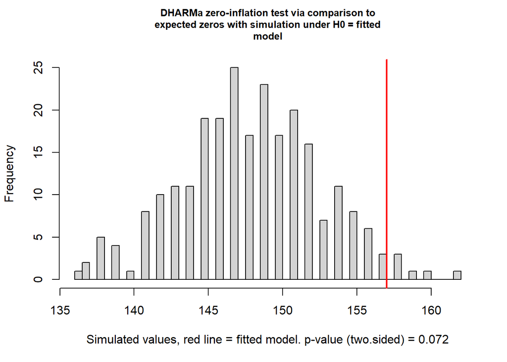

```
##
##  DHARMa zero-inflation test via comparison to expected zeros with
##  simulation under H0 = fitted model
##
## data:  simulationOutput
## ratioObsSim = 1.0603, p-value = 0.072
## alternative hypothesis: two.sided
```

```r
strong.res.sim <- simulateResiduals(strong.poisson.mdl)
testZeroInflation(strong.res.sim)
```

### Overdispersion test for strong fault bars

```r
testOverdispersion(strong.res.sim)
```

```
## testOverdispersion is deprecated, switch your code to using the testDispersion function
```

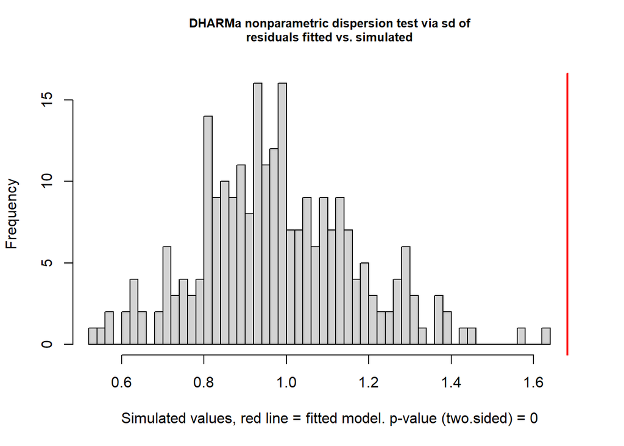

```
##
##  DHARMa nonparametric dispersion test via sd of residuals fitted vs.
##  simulated
##
## data:  simulationOutput
## dispersion = 1.7177, p-value < 2.2e-16
## alternative hypothesis: two.sided
```

### Strong fault bar NB1 model

```r
strong.NB1.mdl <- glmmTMB(data = fbs.df, StrongBars ~ Habitat, family = nbinom1)
```

### Strong bar AIC model comparison

This output suggests that the negative binomial 1 distribution provides the best fit.

```r
strong.NB2.mdl <- update(strong.NB1.mdl, family = nbinom2)
AICtab(strong.poisson.mdl, strong.NB1.mdl, strong.NB2.mdl)
```

```
##                    dAIC df
## strong.NB1.mdl      0.0 3
## strong.NB2.mdl      1.7 3
## strong.poisson.mdl 21.5 2
```

### Best fit strong fault bar model

```r
summary(strong.NB1.mdl)
```

```
##  Family: nbinom1  ( log )
## Formula:          StrongBars ~ Habitat
## Data: fbs.df
##
##      AIC      BIC   logLik deviance df.resid
##    183.3    192.9    -88.7    177.3      176
##
##
## Dispersion parameter for nbinom1 family (): 1.04
##
## Conditional model:
##              Estimate Std. Error z value Pr(>|z|)
## (Intercept)   -2.1298     0.3966  -5.369  7.9e-08 ***
## Habitaturban   0.8381     0.4555   1.840   0.0658 .
## ---
## Signif. codes:  0 '***' 0.001 '**' 0.01 '*' 0.05 '.' 0.1 ' ' 1
```

### Poisson model for total number of fault bars

```r
total.poisson.mdl <- glmmTMB(data = fbs.df, BarsTotal ~ Habitat, family = "poisson")
```

### Total fault bar zero inflation test

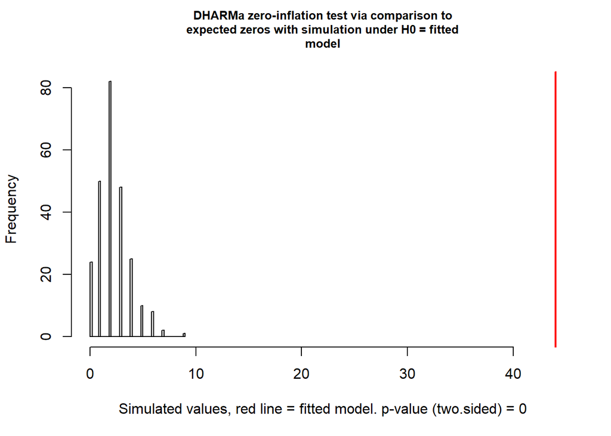

```
##
##  DHARMa zero-inflation test via comparison to expected zeros with
##  simulation under H0 = fitted model
##
## data:  simulationOutput
## ratioObsSim = 18.998, p-value < 2.2e-16
## alternative hypothesis: two.sided
```

```r
total.res.sim <- simulateResiduals(total.poisson.mdl)
testZeroInflation(total.res.sim)
```

### Overdispersion test for total fault bars

```r
testOverdispersion(total.res.sim)
```

```
## testOverdispersion is deprecated, switch your code to using the testDispersion function
```

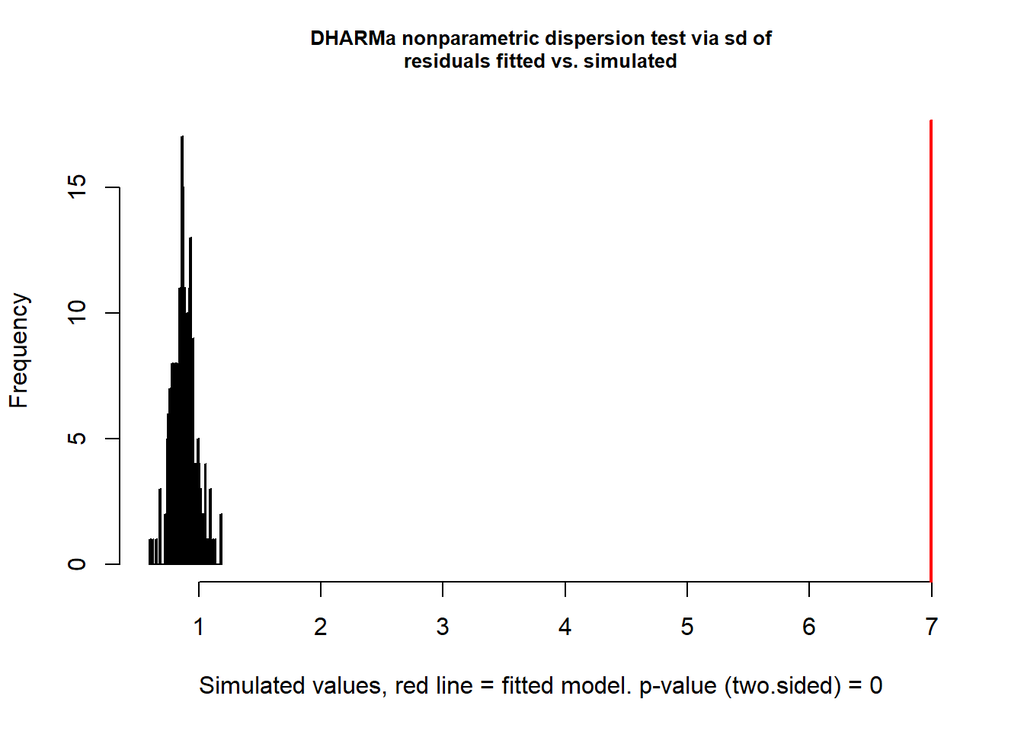

```
##
##  DHARMa nonparametric dispersion test via sd of residuals fitted vs.
##  simulated
##
## data:  simulationOutput
## dispersion = 7.918, p-value < 2.2e-16
## alternative hypothesis: two.sided
```

### Total fault bar ZIP model

```r
total.ZIP.mdl <- glmmTMB(data = fbs.df, BarsTotal ~ Habitat, ziformula = ~1, family = "poisson")
```

### Total fault bar AIC model comparison

```r
total.NB1.mdl <- update(total.ZIP.mdl, family = nbinom1)
total.NB2.mdl <- update(total.ZIP.mdl, family = nbinom2)
AICtab(total.poisson.mdl, total.ZIP.mdl, total.NB1.mdl, total.NB2.mdl)
```

```
##                   dAIC  df
## total.NB2.mdl       0.0 4
## total.NB1.mdl       0.5 4
## total.ZIP.mdl     394.8 3
## total.poisson.mdl 644.9 2
```

### Best fit total fault bar model

```r
summary(total.NB2.mdl)
```

```
##  Family: nbinom2  ( log )
## Formula:          BarsTotal ~ Habitat
## Zero inflation:             ~1
## Data: fbs.df
##
##      AIC      BIC   logLik deviance df.resid
##    937.9    950.6   -464.9    929.9      175
##
##
## Dispersion parameter for nbinom2 family (): 0.676
##
## Conditional model:
##              Estimate Std. Error z value Pr(>|z|)
## (Intercept)    1.6896     0.1352  12.497   <2e-16 ***
## Habitaturban  -0.3469     0.1951  -1.778   0.0754 .
## ---
## Signif. codes:  0 '***' 0.001 '**' 0.01 '*' 0.05 '.' 0.1 ' ' 1
##
## Zero-inflation model:
##             Estimate Std. Error z value Pr(>|z|)
## (Intercept)   -18.56    4214.38  -0.004    0.996
```

### Total fault bar density plot

This plot shows the frequency of total fault bar numbers per feather in the urban and rural samples. The dotted lines are the habitat means.

```r
mean(fbs.df$BarsTotal[fbs.df$Habitat=="urban"])
```

```
## [1] 3.829545
```

```r
mean(fbs.df$BarsTotal[fbs.df$Habitat=="rural"])
```

```
## [1] 5.417582
```

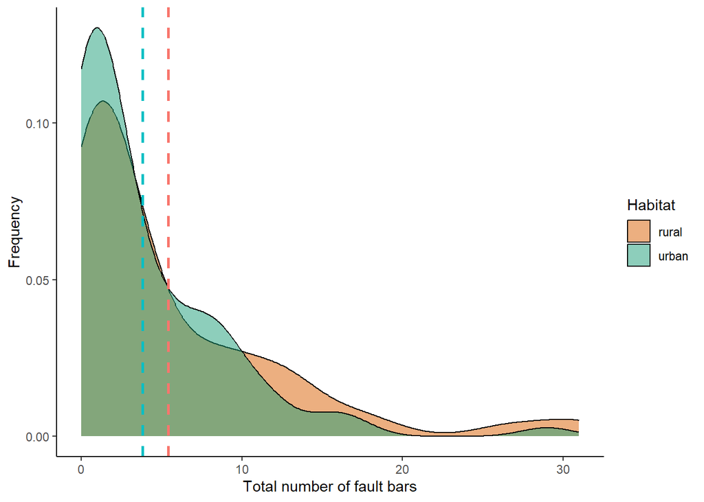

```r
TotHabitat <- c("Urban", "Rural")
TotMeans <- c(3.83, 5.42)
TotHabitatMeans <- data.frame(TotHabitat,TotMeans)

TotalBarDensity.plot <- ggplot(fbs.df, aes(x=BarsTotal, fill = Habitat))+
  geom_density(alpha=0.5)+
  geom_vline(data = HabitatMeans, aes(xintercept = TotMeans, color=TotHabitat),
             linetype="dashed",
             size = 1,
             show.legend = FALSE)+
  scale_fill_manual(values = c("#D95F02", "#1B9E77"))+
  ylab("Frequency")+
  xlab("Total number of fault bars")

TotalBarDensity.plot
```

## To do list

### 1. Restrict by feather type (DONE)

### 2. Combine light and medium fault bars

### 3. Feather weight by Habitat for feather type

### 4. Length of fault bar by Habitat

```r
lpm.poisson.mdl <- glmmTMB(data = fbs.df, LightPlusMedium ~ Habitat, family = "poisson")
```

### LightPlusMedium fault bar zero inflation test

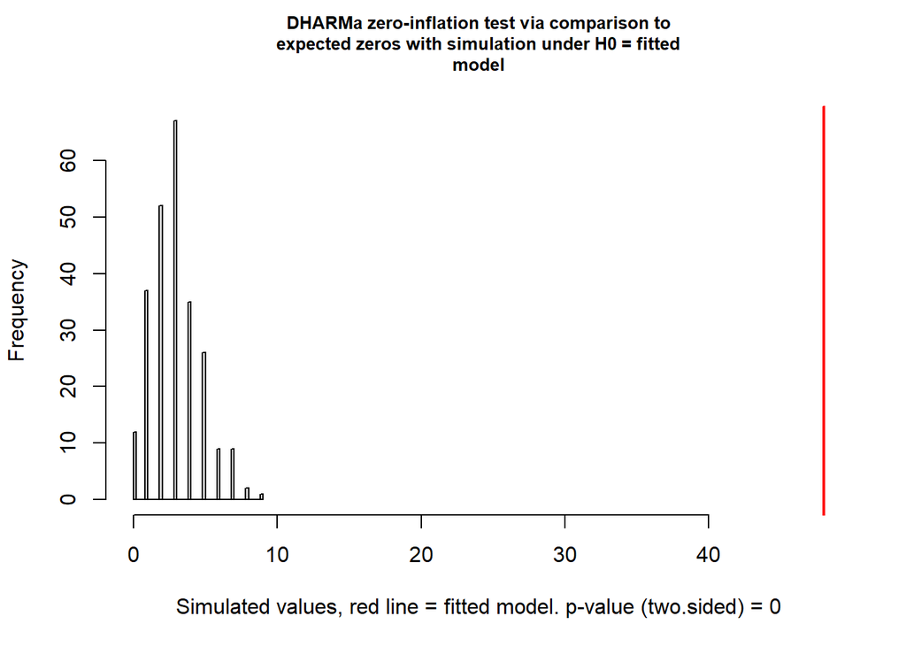

```
##
##  DHARMa zero-inflation test via comparison to expected zeros with
##  simulation under H0 = fitted model
##
## data:  simulationOutput
## ratioObsSim = 15.915, p-value < 2.2e-16
## alternative hypothesis: two.sided
```

```r
lpm.res.sim <- simulateResiduals(lpm.poisson.mdl)
testZeroInflation(lpm.res.sim)
```

### Overdispersion test for lpm fault bars

```r
testOverdispersion(lpm.res.sim)
```

```
## testOverdispersion is deprecated, switch your code to using the testDispersion function
```

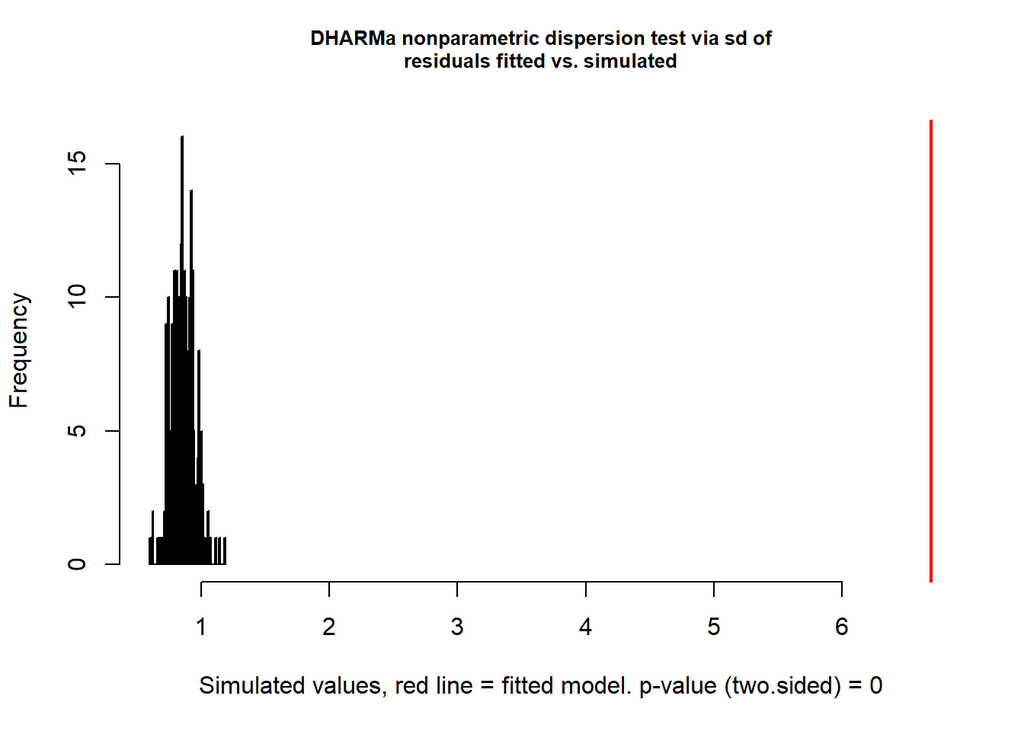

```
##
##  DHARMa nonparametric dispersion test via sd of residuals fitted vs.
##  simulated
##
## data:  simulationOutput
## dispersion = 7.7715, p-value < 2.2e-16
## alternative hypothesis: two.sided
```

### LightPlusMedium ZIP model

```r
lpm.ZIP.mdl <- glmmTMB(data = fbs.df, LightPlusMedium ~ Habitat, ziformula = ~1, family = "poisson")
```

### LPM fault bar AIC model comparison

```r
lpm.NB1.mdl <- update(lpm.ZIP.mdl, family = nbinom1)
lpm.NB2.mdl <- update(lpm.ZIP.mdl, family = nbinom2)
AICtab(lpm.poisson.mdl, lpm.ZIP.mdl, lpm.NB1.mdl, lpm.NB2.mdl)
```

```
##                 dAIC  df
## lpm.NB1.mdl       0.0 4
## lpm.NB2.mdl       0.9 4
## lpm.ZIP.mdl     376.5 3
## lpm.poisson.mdl 638.8 2
```

### Best fit LPM model

```r
summary(lpm.NB1.mdl)
```

```
##  Family: nbinom1  ( log )
## Formula:          LightPlusMedium ~ Habitat
## Zero inflation:                   ~1
## Data: fbs.df
##
##      AIC      BIC   logLik deviance df.resid
##    918.9    931.6   -455.4    910.9      175
##
##
## Dispersion parameter for nbinom1 family (): 7.05
##
## Conditional model:
##              Estimate Std. Error z value Pr(>|z|)
## (Intercept)    1.6468     0.1202  13.699   <2e-16 ***
## Habitaturban  -0.3475     0.1621  -2.144    0.032 *
## ---
## Signif. codes:  0 '***' 0.001 '**' 0.01 '*' 0.05 '.' 0.1 ' ' 1
##
## Zero-inflation model:
##             Estimate Std. Error z value Pr(>|z|)
## (Intercept)   -19.06    4759.94  -0.004    0.997
```

## Subsetting by feather type

### Primary feather subset

```r
fbs.prim.df <- subset(fbs.df, Type == "primary")
```

```r
summary(glmmTMB(data = fbs.prim.df, BarsTotal ~ Habitat, ziformula = ~1, family = "poisson"))
```

```
##  Family: poisson  ( log )
## Formula:          BarsTotal ~ Habitat
## Zero inflation:             ~1
## Data: fbs.prim.df
##
##      AIC      BIC   logLik deviance df.resid
##    277.8    284.1   -135.9    271.8       56
##
##
## Conditional model:
##              Estimate Std. Error z value Pr(>|z|)
## (Intercept)    1.4235     0.1118  12.733   <2e-16 ***
## Habitaturban  -0.2405     0.1848  -1.302    0.193
## ---
## Signif. codes:  0 '***' 0.001 '**' 0.01 '*' 0.05 '.' 0.1 ' ' 1
##
## Zero-inflation model:
##             Estimate Std. Error z value Pr(>|z|)
## (Intercept)  -0.5260     0.2818  -1.866    0.062 .
## ---
## Signif. codes:  0 '***' 0.001 '**' 0.01 '*' 0.05 '.' 0.1 ' ' 1
```

### Primary feather light fault bar Poisson model

Significantly fewer in urban habitat

```r
prim.light.poisson.mdl <- glmmTMB(data = fbs.prim.df, LightBars ~ Habitat, family = "poisson")
summary(prim.light.poisson.mdl)
```

```
##  Family: poisson  ( log )
## Formula:          LightBars ~ Habitat
## Data: fbs.prim.df
##
##      AIC      BIC   logLik deviance df.resid
##    303.7    307.9   -149.8    299.7       57
##
##
## Conditional model:
##              Estimate Std. Error z value Pr(>|z|)
## (Intercept)    0.8224     0.1231   6.681 2.38e-11 ***
## Habitaturban  -0.5860     0.2036  -2.878  0.00401 **
## ---
## Signif. codes:  0 '***' 0.001 '**' 0.01 '*' 0.05 '.' 0.1 ' ' 1
```

### Zero inflation test for primary feather light fault bars

Still strongly zero-inflated data

```r
#zero inflation test from: http://data.princeton.edu/wws509/r/overdispersion.html
zobs <- fbs.prim.df$LightBars == 0
zpoi <- exp(-exp(predict(prim.light.poisson.mdl)))
c(obs=mean(zobs), poi = mean(zpoi))
```

```
##       obs       poi
## 0.5423729 0.1937564
```

### Primary feather light fault bar ZIP model

Nonsignificant relationship

```r
prim.light.ZIP.mdl <- glmmTMB(data = fbs.prim.df, LightBars ~ Habitat, ziformula = ~1, family = "poisson")
summary(prim.light.ZIP.mdl)
```

```
##  Family: poisson  ( log )
## Formula:          LightBars ~ Habitat
## Zero inflation:             ~1
## Data: fbs.prim.df
##
##      AIC      BIC   logLik deviance df.resid
##    228.7    234.9   -111.3    222.7       56
##
##
## Conditional model:
##              Estimate Std. Error z value Pr(>|z|)
## (Intercept)    1.4710     0.1260  11.672   <2e-16 ***
## Habitaturban  -0.3824     0.2193  -1.744   0.0812 .
## ---
## Signif. codes:  0 '***' 0.001 '**' 0.01 '*' 0.05 '.' 0.1 ' ' 1
##
## Zero-inflation model:
##             Estimate Std. Error z value Pr(>|z|)
## (Intercept)   0.1048     0.2710   0.387    0.699
```

### Primary feather medium fault bar ZIP model

Nonsignificant relationship

```r
summary(glmmTMB(data = fbs.prim.df, MediumBars ~ Habitat, ziformula = ~1, family = "poisson"))
```

```
##  Family: poisson  ( log )
## Formula:          MediumBars ~ Habitat
## Zero inflation:              ~1
## Data: fbs.prim.df
##
##      AIC      BIC   logLik deviance df.resid
##    108.4    114.6    -51.2    102.4       56
##
##
## Conditional model:
##              Estimate Std. Error z value Pr(>|z|)
## (Intercept)    0.6227     0.2792   2.230   0.0257 *
## Habitaturban  -0.1134     0.4772  -0.238   0.8122
## ---
## Signif. codes:  0 '***' 0.001 '**' 0.01 '*' 0.05 '.' 0.1 ' ' 1
##
## Zero-inflation model:
##             Estimate Std. Error z value Pr(>|z|)
## (Intercept)   1.0118     0.3591   2.818  0.00484 **
## ---
## Signif. codes:  0 '***' 0.001 '**' 0.01 '*' 0.05 '.' 0.1 ' ' 1
```

### Secondary feather subset

```r
fbs.sec.df <- subset(fbs.df, Type == "secondary")
```

### Secondary feather light fault bar ZIP model

Nonsignificant relationship

```r
summary(glmmTMB(data = fbs.sec.df, LightBars ~ Habitat, ziformula = ~1, family = "poisson"))
```

```
##  Family: poisson  ( log )
## Formula:          LightBars ~ Habitat
## Zero inflation:             ~1
## Data: fbs.sec.df
##
##      AIC      BIC   logLik deviance df.resid
##    274.9    281.2   -134.4    268.9       58
##
##
## Conditional model:
##              Estimate Std. Error z value Pr(>|z|)
## (Intercept)    1.5546     0.1103  14.096   <2e-16 ***
## Habitaturban  -0.1870     0.1673  -1.118    0.264
## ---
## Signif. codes:  0 '***' 0.001 '**' 0.01 '*' 0.05 '.' 0.1 ' ' 1
##
## Zero-inflation model:
##             Estimate Std. Error z value Pr(>|z|)
## (Intercept)  -0.3302     0.2642   -1.25    0.211
```

### Secondary feather medium fault bar ZIP model

Significantly MORE medium fault bars in the secondary feathers

```r
summary(glmmTMB(data = fbs.sec.df, MediumBars ~ Habitat, ziformula = ~1, family = "poisson"))
```

```
##  Family: poisson  ( log )
## Formula:          MediumBars ~ Habitat
## Zero inflation:              ~1
## Data: fbs.sec.df
##
##      AIC      BIC   logLik deviance df.resid
##    179.2    185.5    -86.6    173.2       58
##
##
## Conditional model:
##              Estimate Std. Error z value Pr(>|z|)
## (Intercept)    0.5325     0.1875   2.840  0.00452 **
## Habitaturban   0.5824     0.2933   1.985  0.04712 *
## ---
## Signif. codes:  0 '***' 0.001 '**' 0.01 '*' 0.05 '.' 0.1 ' ' 1
##
## Zero-inflation model:
##             Estimate Std. Error z value Pr(>|z|)
## (Intercept)   0.1104     0.2876   0.384    0.701
```

### Tail feather subset

```r
fbs.tail.df <- subset(fbs.df, Type == "tail")
```

### Tail feather light fault bar ZIP model

Significantly fewer light fault bars in the urban habitat

```r
summary(glmmTMB(data = fbs.tail.df, LightBars ~ Habitat, ziformula = ~1, family = "poisson"))
```

```
##  Family: poisson  ( log )
## Formula:          LightBars ~ Habitat
## Zero inflation:             ~1
## Data: fbs.tail.df
##
##      AIC      BIC   logLik deviance df.resid
##    368.8    375.0   -181.4    362.8       56
##
##
## Conditional model:
##              Estimate Std. Error z value Pr(>|z|)
## (Intercept)   1.77636    0.08268  21.484   <2e-16 ***
## Habitaturban -0.29386    0.13518  -2.174   0.0297 *
## ---
## Signif. codes:  0 '***' 0.001 '**' 0.01 '*' 0.05 '.' 0.1 ' ' 1
##
## Zero-inflation model:
##             Estimate Std. Error z value Pr(>|z|)
## (Intercept)  -1.3030     0.3243  -4.018 5.87e-05 ***
## ---
## Signif. codes:  0 '***' 0.001 '**' 0.01 '*' 0.05 '.' 0.1 ' ' 1
```

### Tail feather medium fault bar ZIP model

Significantly fewer medium fault bars in urban habitat

```r
summary(glmmTMB(data = fbs.tail.df, MediumBars ~ Habitat, ziformula = ~1, family = "poisson"))
```

```
##  Family: poisson  ( log )
## Formula:          MediumBars ~ Habitat
## Zero inflation:              ~1
## Data: fbs.tail.df
##
##      AIC      BIC   logLik deviance df.resid
##    365.9    372.1   -179.9    359.9       56
##
##
## Conditional model:
##              Estimate Std. Error z value Pr(>|z|)
## (Intercept)   1.68632    0.08846  19.064   <2e-16 ***
## Habitaturban -0.32854    0.15021  -2.187   0.0287 *
## ---
## Signif. codes:  0 '***' 0.001 '**' 0.01 '*' 0.05 '.' 0.1 ' ' 1
##
## Zero-inflation model:
##             Estimate Std. Error z value Pr(>|z|)
## (Intercept)  -1.0429     0.3055  -3.414 0.000641 ***
## ---
## Signif. codes:  0 '***' 0.001 '**' 0.01 '*' 0.05 '.' 0.1 ' ' 1
```